# Michael Hornsby EDRM 878 Assignment 1 Notebook

Problem Set 1.9

Part 1)

```r
data(blocks)

blocks$Trial <- as.factor(blocks$Trial)
blocks$Shape <- as.factor(blocks$Shape)

summary(blocks)
```

```
     Child        Number           Time        Trial       Shape         Age
 A      : 4   Min.   : 3.00   Min.   :  6.00   1:50   Cube    :50   Min.   :2.420
 B      : 4   1st Qu.: 5.00   1st Qu.: 14.40   2:50   Cylinder:50   1st Qu.:3.670
 C      : 4   Median : 6.00   Median : 20.20                        Median :4.000
 D      : 4   Mean   : 6.82   Mean   : 29.59                        Mean   :4.026
 E      : 4   3rd Qu.: 8.00   3rd Qu.: 35.00                        3rd Qu.:4.580
 F      : 4   Max.   :13.00   Max.   :178.00                        Max.   :5.080
 (Other):76
```

Part 2)

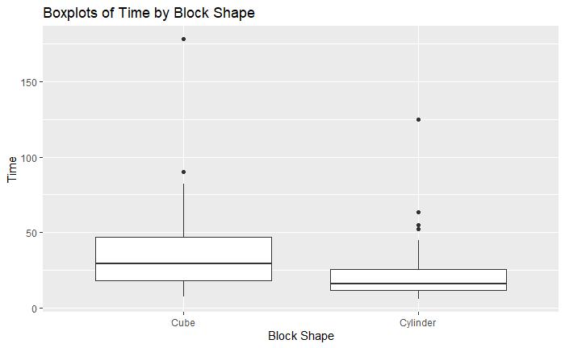

```r
blocks %>%
  ggplot(aes(x = Shape, y = Time)) +
  geom_boxplot() +
  labs(title = "Boxplots of Time by Block Shape",
       x = "Block Shape")
```

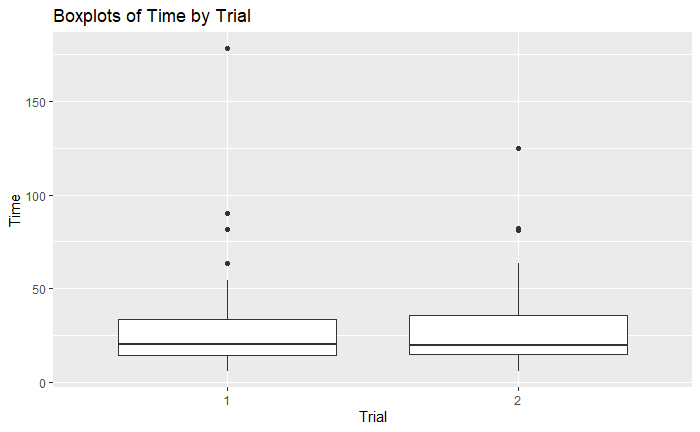

```r
blocks %>%
  ggplot(aes(x = Trial, y = Time)) +
  geom_boxplot() +
  labs(title = "Boxplots of Time by Trial")
```

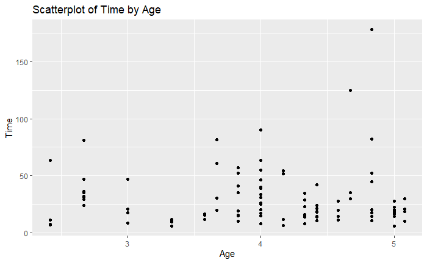

```r
blocks %>%
  ggplot(aes(x = Age, y = Time)) +
  geom_point() +
  labs(title = "Scatterplot of Time by Age")
```

Part 3

Looking at the boxplots of time taken by block shape, it appears as though using cube blocks resulted in an overall longer time taken. I think I would have expected the opposite. I would have guessed children would be quicker at stacking cubes than cylinders. Looking at the boxplots of time by trial, it looks as though children took about the same time for both trials. As a general trend in the scatterplot, there doesn’t seem to be an effect of age on time. If I ignore those 2 points greater than a time of 125, there doesn’t seem to be an significant relationship that I can visualize form the scatterplot.

Part 4

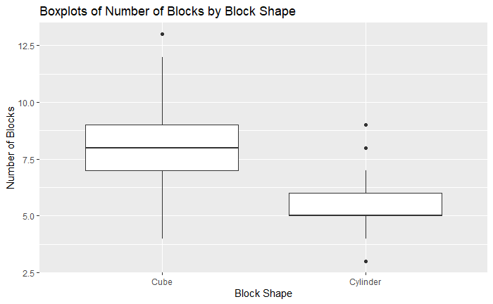

```r
blocks %>%
  ggplot(aes(x = Shape, y = Number)) +
  geom_boxplot() +
  labs(title = "Boxplots of Number of Blocks by Block Shape",
       x = "Block Shape",
       y = "Number of Blocks")
```

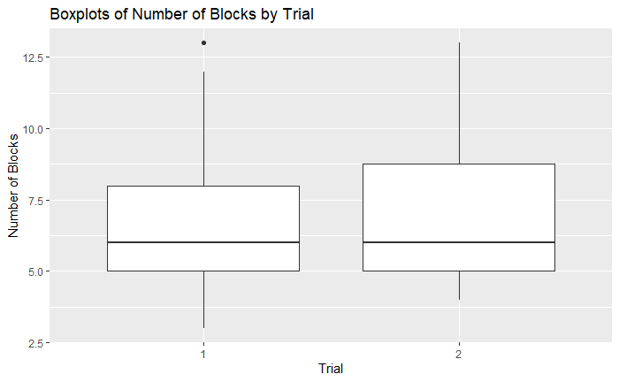

```r
blocks %>%
  ggplot(aes(x = Trial, y = Number)) +
  geom_boxplot() +
  labs(title = "Boxplots of Number of Blocks by Trial",
       y = "Number of Blocks")
```

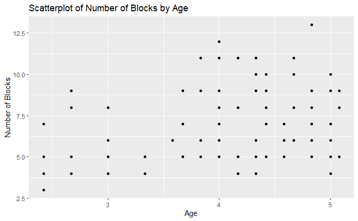

```r
blocks %>%
  ggplot(aes(x = Age, y = Number)) +
  geom_point() +
  labs(title = "Scatterplot of Number of Blocks by Age",
       y = "Number of Blocks")
```

Part 5)

Looking at the boxplots of Number by Shape, it appears as though children using cubes used more blocks than children using cylinders on a fairly consistant basis. Children at trial 2 appear to use slightly more blocks than at trial 1, although, I wouldn’t think this effect would be significant at any reasonable alpha level looking at the boxplots. Looking at the scatterplot of number of blocks by age, there does appear to be a slightly positive linear relationship between number of blocks and age. As age increases, the number of blocks used on average appears to increase slightly.

Problem Set 2.18)

Part 1)

Block shape does appear to have an effect on time taken. As stated above, it looks as though children using cylinders took less time overall than children using cubes, although it isn’t apparent immediately to me if the effect will be significant at any reasonable alpha level. The two block shape groups do not appear to really have equal variance nor do they look exactly normal given their visible upward skew. Trial does not appear to affect time at all when looking at the boxplots. It isn’t apparent to be me immediately when looking at the scatterplot of time by age whether age will have any significant effect. However, even if a significant effect of age on time is found, I would wonder whether or not that effect would still be present if those 2 times greater than 125 didn’t have enough weight to create an effect. Those two points aside, I wouldn’t be on any significant age effect.

Part 2)

If we assume that age, shape, and the interaction effect of age and shape are significant and provide an appropriate model for the data, we can conclude a few things. The amount of time taken significantly changes with age. The amount of time taken also significantly differs between the two shapes. Additionally, there is a significant interaction between age and shape such that as children age they become ‘proficient’ in stacking blocks of one type at a faster rate than they do of the other type. (I am assuming that children will not become less proficient at stacking blocks, although negative relationships and interactions are possible.)

Part 3)

If we assume that age, trial, and the interaction effect of age and trial are significant and provide an appropriate model for the data, we can conclude a few things. The amount of time taken significantly changes with age. The amount of time taken also significantly differs between the two trials. Additionally, there is a significant interaction between age and trial such that the slope of time by age differs significantly between the two trials.

Part 4)

This systematic component, given all effects are significant, claims that age, shape, trial, the interaction of age and trial, and the interaction of shape and trial are significant. (Or, depending on the effects and significance, could just mean the interactions may be significance. I know that is a whole debate by itself.) If we assume all effects are significant, we know that time differs significantly with age, by shape, and by trial. Additionally, the slope of time by age differs for block shape AND for trial.

Part 5)

```r
anova(lm(Time ~ Shape, data = blocks))
```

```
Analysis of Variance Table

Response: Time
          Df Sum Sq Mean Sq F value   Pr(>F)
Shape      1   5219  5218.6  8.5396 0.004315 **
Residuals 98  59889   611.1
---
Signif. codes:  0 ‘***’ 0.001 ‘**’ 0.01 ‘*’ 0.05 ‘.’ 0.1 ‘ ’ 1
```

We see here that time does differ significantly between block shapes at any reasonable alpha level with a p-value of 0.004315.

Part 6)

```r
anova(lm(Time ~ Age * Shape, data = blocks))
```

```
Analysis of Variance Table

Response: Time
          Df Sum Sq Mean Sq F value   Pr(>F)
Age        1      9     8.5  0.0137 0.907028
Shape      1   5219  5218.6  8.3834 0.004688 **
Age:Shape  1    121   120.7  0.1939 0.660683
Residuals 96  59760   622.5
---
Signif. codes:  0 ‘***’ 0.001 ‘**’ 0.01 ‘*’ 0.05 ‘.’ 0.1 ‘ ’ 1
```

```r
anova(lm(Time ~ Age, data = blocks))
```

```
Analysis of Variance Table

Response: Time
          Df Sum Sq Mean Sq F value Pr(>F)
Age        1      9    8.54  0.0128   0.91
Residuals 98  65099  664.27
```

When looking at these two models, we can see that we cannot conclude that older children take less time when accounting for block type. Additionally, we cannot conclude that older children take less time to build the towers at all. The p-values of age and the p-value of the age:shape interaction are not significant in either model at any reasonable alpha level. As confirmed in the scatterplot above, age is not a significant predictor of time taken.

Part 7)

```r
anova(lm(Time ~ Shape, data = blocks))
```

```
Analysis of Variance Table

Response: Time
          Df Sum Sq Mean Sq F value   Pr(>F)
Shape      1   5219  5218.6  8.5396 0.004315 **
Residuals 98  59889   611.1
---
Signif. codes:  0 ‘***’ 0.001 ‘**’ 0.01 ‘*’ 0.05 ‘.’ 0.1 ‘ ’ 1
```

Part 8)

The significant predictor of time taken to build the towers is the shape of the blocks used. The shape variable has a p-value of 0.004315, which is significant at any reasonable alpha level. We can conclude that children using cylinders take significantly less time to build the towers than children using cube blocks on average.